# AI: K-Nearest Neighbors

## Classification problem with KNN: should we give a loan or no?

In this project I use my own designed K-Nearest Neighbors and DataTable packages to predict if a person with respective attributes will pay loan back.

I'll walk you through this process of model definition, fine-tuning and evaluation. You might want to jump to the interesting section immediately.

Before exploring this work with KNN, go explore first [Logistic Regression note](https://github.com/kotsky/ai-dev/blob/main/logistic_regression_workflow.ipynb) which covers same data set. It's done to compare results of 2 different classification algorithms.

1. Section 1- preparation
2. Section 2- model building
3. Section 3- k-evaluation
4. Section 4- results

# Introduction

I had developed my own Pandas-like simplified package data_reader.py to fetch different kind of data faster than Pandas can do and contains main features for KNN AI like data preparation for training/testing, split data, adding new features, creating combined one, ploting and many others.

In addition, to enhance my AI regression model's knowledge, I designed a knn.py package based on **a special k-size max heap data structure** to optimize a speed and memory complexities storing/comparing of nearest points to unknown data point. Moreover there is logs feature to monitor regression model learning and evaluation of its performance.

All these features and techniques I would like to show in this notebook.

For additional package usage, refer to doxy in its src code.

For that session, I'm going to use a /data/loan_train.csv file, which contains table-like structure data of various cases when a person returns/not returns his loan back. It might be interesting to try to predict if the given person can get loan.

# Section 1 - preparation

```python
import classification.knn as knn
import data_reader as dr
import matplotlib.pyplot as plt
from helper_methods import *
```

```python
# Use same data as it was in LR work
main_data = dr.DataTable("data/loan_train.csv")
```

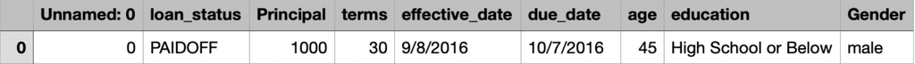

```python
main_data.head
```

```
['',
 'Unnamed: 0',
 'loan_status',
 'Principal',
 'terms',
 'effective_date',
 'due_date',
 'age',
 'education',
 'Gender']
```

Loan_status is going to be our target which we try to predict. It has 2 options: PAIDOFF and COLLECTION. DataTable helps to read csv file in a way that words (as a string data type) will be converted to numbers, which we can easily restore back.

```python
target_name = "loan_status"
main_data.select_target(target_name)
main_data.target[target_name].data[0:5]
```

```
Target loan_status was added
```

```
[1, 1, 1, 1, 1]
```

```python
main_data.class_dict[target_name]  # to check which number represent which word
```

```
[{'_count': 2, 'COLLECTION': 0, 'PAIDOFF': 1}, {0: 'COLLECTION', 1: 'PAIDOFF'}]
```

So, COLLECTION is 0, and PAIDOFF is 1. With that, let's move further. What about features?

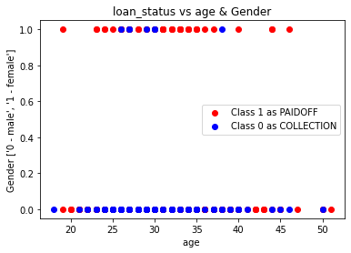

```python
main_data.plot(parameter1='age', parameter2='Gender', classifier=target_name)
```

Well, we can see that we don't have strongly marked relationship between features and target. Might be hard to predict with hight accurace loan returning. But we will try.

# Section 2 - model building

Let's create the same model as we had for Logistic regression, so we can compare their results.

```python
main_data.activate_features(['Principal',
 'terms',
 'effective_date',
 'age',
 'education',
 'Gender'])
main_data.add_new_feature(['education', 'age'])
main_data.add_new_feature(['Gender', 'age'])
```

```
Feature Principal was added
Feature terms was added
Feature effective_date was added
Feature age was added
Feature education was added
Feature Gender was added
New created feature education*age was added
This education*age feature is added to the list of training set
New created feature Gender*age was added
This Gender*age feature is added to the list of training set
```

```python
main_data.max_scaling()
```

```
Column  was scaled
Column Unnamed: 0 was scaled
Column loan_status was scaled
Column Principal was scaled
Column terms was scaled
Column effective_date was scaled
Column due_date was scaled
Column age was scaled
Column education was scaled
Column Gender was scaled
Column education*age was scaled
Column Gender*age was scaled
```

```python
main_data.split_data(0.6, shuffle=True)
```

```
Shuffle was done
Data was split as follows: 0.6 training set and 0.4 testing set
```

```python
training_features_data, training_target_data = main_data.get_training_data()  # returns (features data, target data)
# cv_data = main_data.get_cv_data()
testing_data = main_data.get_testing_data()
```

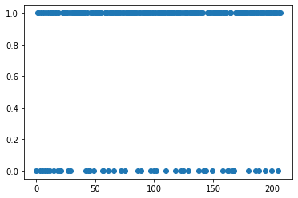

```python
# check how 0 and 1 were split after shuffling
axis_x = [x for x in range(len(training_target_data))]
plt.scatter(axis_x, training_target_data)
plt.show()
```

```python
model_knn = knn.KNN()
```

```python
model_knn.set_data([training_features_data, training_target_data])
```

```python
model_knn.set_labels = main_data.get_labels()
```

```python
model_knn.set_labels  # to check what we have in our model
```

```
(['Principal',
  'terms',
  'effective_date',
  'age',
  'education',
  'Gender',
  'education*age',
  'Gender*age'],
 'loan_status')
```

# Section 3 - k-evaluation

In this section I would like to explore which value of k might be the best for our model to predict.

```python
def get_accuracy_from_cm(cm):
    accuracy = (cm[0][0] + cm[1][1]) / (cm[0][0] + cm[1][1] + cm[0][1] + cm[1][0])
    return round(accuracy, 2)

k_array = [1, 3, 5, 7, 9, 11]
accuracy_array = []
precision_array = []
recall_array = []
f1_score_array = []

for k in k_array:
    model_knn.k_nn = k
    confusion_matrix, precision, recall = model_knn.evaluation(testing_data)
    precision_array.append(precision)
    recall_array.append(recall)
    accuracy_array.append(get_accuracy_from_cm(confusion_matrix))
    f1_score_array.append(2 * precision * recall / (precision + recall))
```

```python
accuracy_array
```

```
[0.71, 0.71, 0.72, 0.72, 0.7, 0.71]
```

```python
f1_score_array
```

```
[0.8198198198198199,
 0.824561403508772,
 0.8266666666666668,
 0.8296943231441049,
 0.8141592920353982,
 0.8275862068965517]
```

```python
recall_array
```

```
[0.900990099009901,
 0.9306930693069307,
 0.9207920792079208,
 0.9405940594059405,
 0.9108910891089109,
 0.9504950495049505]
```

```python
precision_array
```

```
[0.7520661157024794,
 0.7401574803149606,
 0.75,
 0.7421875,
 0.736,
 0.732824427480916]
```

# Section 4 - results